# LDA final project

Kaitlin Maciejewski, Morgan de Ferrante, Bingnan Li, Volha Tryputsen

# Exploratory

## (1): Smoking ~ age, sex

### Is there a relationship between age and smoking status?

ANS: Yes, the proportion of smokers decreases with the age.

```r
smoke_v_age = data %>%
  select(cursmoke, age) %>%
  ggplot(aes(x = age, y = cursmoke)) +
  geom_jitter(height = 0.1, alpha = 0.1) +
  geom_smooth(lwd = 1.5) +
  theme_bw()
```

### Does this relationship differ by sex?

ANS: There is a higher proportion of smoker among men compared to women as both age ,but there is no interaction between age and sex.

```r
smoke_age_sex = data %>%
  select(cursmoke, age, sex) %>%
  ggplot(aes(x = age, y = cursmoke, group = sex, color = sex)) +
  geom_jitter(height = 0.1, alpha = 0.1) +
  geom_smooth(lwd = 1.5) +
  theme_bw()
```

## (2) number of cigarettes ~ age, sex

### Is there a relationship between the number of cigarettes smoked per day and age?

ANS: Yes, number of sigarets smoked per day stays constant for 30-50 years old and decreases with age after 50 years old.

#### All

```r
n_c_age_all = data %>%
  select(cigpday, age) %>%
  ggplot(aes(x = age, y = cigpday)) +
  geom_jitter(height = 0.1, alpha = 0.1) +
  geom_smooth(lwd = 1.5) +
  theme_bw()
```

#### Smokers only

```r
n_c_age_smoke = data %>%
  select(cigpday, age) %>%
  filter(cigpday > 0) %>%
  ggplot(aes(x = age, y = cigpday)) +
  geom_jitter(height = 0.1, alpha = 0.1) +
  geom_smooth(lwd = 1.5) +
  theme_bw()
```

### Does this relationship differ by sex?

ANS: There is sex effect (men smoke higer number of sigarets per day than women across age), but there is no sex and age interaction.

#### All

```r
n_c_age_s_all = data %>%
  select(cigpday, age, sex) %>%
  ggplot(aes(x = age, y = cigpday, group = sex, color = sex)) +
  geom_jitter(height = 0.1, alpha = 0.1) +
  geom_smooth(lwd = 1.5) +
  theme_bw()
```

#### Smokers only

```r
n_c_age_s_smoke = data %>%
  select(cigpday, age, sex) %>%
  filter(cigpday > 0) %>%
  ggplot(aes(x = age, y = cigpday, group = sex, color = sex)) +
  geom_jitter(height = 0.1, alpha = 0.1) +
  geom_smooth(lwd = 1.5) +
  theme_bw()
```

## Smoking vs. health outcomes

## (1) The relationship between current smoking status and systolic blood pressure.

### smoking ~ sysbp

ANS: Proportion of smokers decreases with increase of systolic blood presure

```r
smoke_sbp = data %>%
  select(cursmoke, sysbp) %>%
  ggplot(aes(x = sysbp, y = cursmoke)) +
  geom_jitter(height = 0.1, alpha = 0.1) +
  geom_smooth(lwd = 1.5) +
  theme_bw()
```

ANS: slightly higher sysbp for non-smokers

```r
smoke_sysbp_status = data %>%
  select(cursmoke, sysbp) %>%
  mutate(cursmoke = factor(cursmoke)) %>%
  ggplot(aes(y = sysbp, x = cursmoke)) +
  geom_boxplot(outlier.colour = "white") +
  theme_bw()
```

### smoking ~ sysbp, sex

ANS: Proportion of smokers decreases with increase of systolic blood presure; the proportion is higher for men (sex effect).

```r
smoke_sysbp_sex = data %>%
  select(cursmoke, sysbp, sex) %>%
  ggplot(aes(x = sysbp, y = cursmoke, group = sex, color = sex)) +
  geom_jitter(height = 0.1, alpha = 0.1) +
  geom_smooth(lwd = 1.5) +
  theme_bw()
```

ANS: no differences in sysbp between male and female smokers and non-smokers

```r
smoke_sysbp_sex_status = data %>%
  select(cursmoke, sex, sysbp) %>%
  mutate(cursmoke = factor(cursmoke),
           smoke_sex = interaction(cursmoke, sex)) %>%
  ggplot(aes(y = sysbp, x = smoke_sex)) +
  geom_boxplot(outlier.colour = "white") +
  theme_bw()
```

## (2) The relationship between current smoking status and diastolic blood pressure.

### smoking ~ diabp

ANS: Proportion of smokers decreases with increase of diastolic blood presure for BP=100 ad then proportion increases again (latter could be due to not enough data)

```r
smoke_dbp = data %>%
  select(cursmoke, diabp) %>%
  ggplot(aes(x = diabp, y = cursmoke)) +
  geom_jitter(height = 0.1, alpha = 0.1) +
  geom_smooth(lwd = 1.5) +
  theme_bw()
```

ANS: no difference

```r
smoke_dbp_box = data %>%
  select(cursmoke, diabp) %>%
  mutate(cursmoke = factor(cursmoke)) %>%
  ggplot(aes(y = diabp, x = cursmoke)) +
  geom_boxplot(outlier.colour = "white") +
  theme_bw()
```

### smoking ~ diabp, sex

ANS: Proportion of smokers decreases with increase of diastolic blood presure; the proprtions are higher for men (sex effect).

```r
smoke_dbp_s = data %>%
  select(cursmoke, diabp, sex) %>%
  ggplot(aes(x = diabp, y = cursmoke, group = sex, color = sex)) +
  geom_jitter(height = 0.1, alpha = 0.1) +
  geom_smooth(lwd = 1.5) +
  theme_bw()
```

ANS: no difference

```r
smoke_dbp_s_bp = data %>%
  select(cursmoke, sex, diabp) %>%
  mutate(cursmoke = factor(cursmoke),
           smoke_sex = interaction(cursmoke, sex)) %>%
  ggplot(aes(y = diabp, x = smoke_sex)) +
  geom_boxplot(outlier.colour = "white") +
  theme_bw()
```

## (3) The relationship between current smoking status and serum total cholesterol.

### smoking ~ totchol

ANS: Proportion of smokers slightly decreases with increase of total cholesterol values

```r
smoke_tc = data %>%
  select(cursmoke, totchol) %>%
  ggplot(aes(x = totchol, y = cursmoke)) +
  geom_jitter(height = 0.1, alpha = 0.1) +
  geom_smooth(lwd = 1.5) +
  theme_bw()
```

ANS: no difference

```r
smoke_tc_bp = data %>%
  select(cursmoke, totchol) %>%
  mutate(cursmoke = factor(cursmoke)) %>%
  ggplot(aes(y = totchol, x = cursmoke)) +
  geom_boxplot(outlier.colour = "white") +
  theme_bw()
```

### smoking ~ totchol, sex [!!!]

ANS: Proportion of smokers hasnonlinera relationship with total cholesterol for women; proprtions increases with increase in total cholesterol for men (sex by totchol interaction effect).

```r
smoke_tc_sex = data %>%
  select(cursmoke, totchol, sex) %>%
  ggplot(aes(x = totchol, y = cursmoke, group = sex, color = sex)) +
  geom_jitter(height = 0.1, alpha = 0.1) +
  geom_smooth(lwd = 1.5) +
  theme_bw()
```

ANS: no difference

```r
smoke_tc_sex_bp = data %>%
  select(cursmoke, sex, totchol) %>%
  mutate(cursmoke = factor(cursmoke),
           smoke_sex = interaction(cursmoke, sex)) %>%
  ggplot(aes(y = totchol, x = smoke_sex)) +
  geom_boxplot(outlier.colour = "white") +
  theme_bw()
```

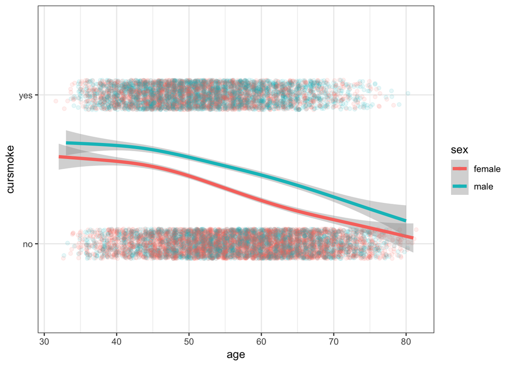

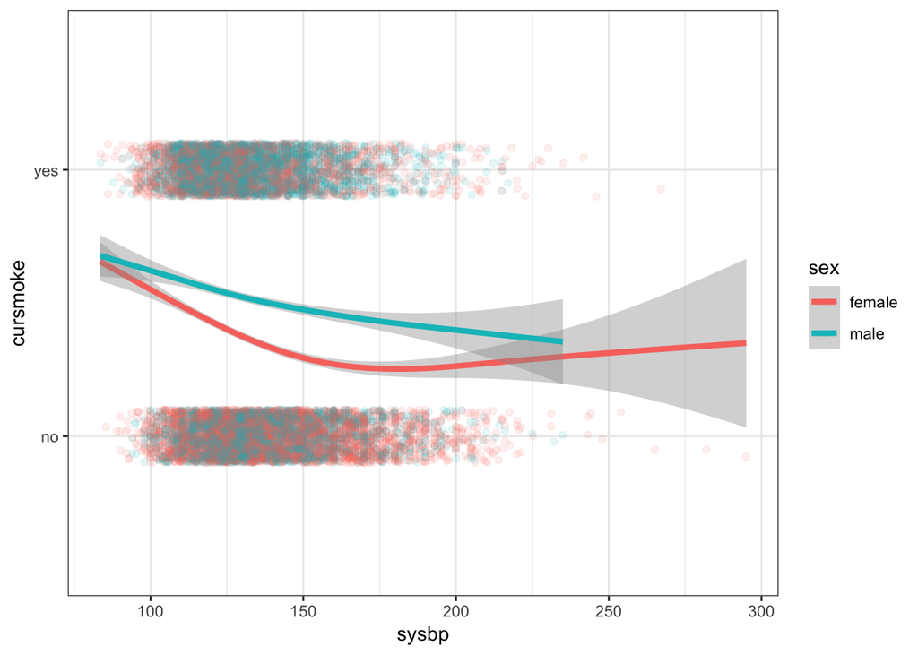

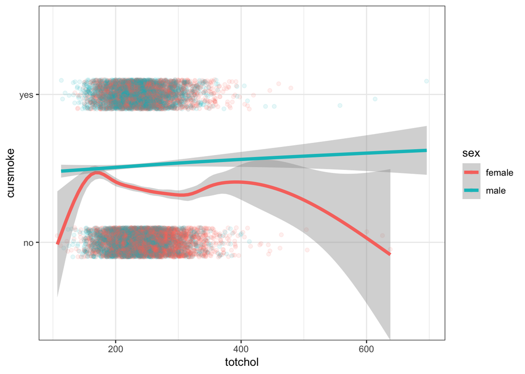

```r
smoke_age_sex
smoke_sysbp_sex
smoke_tc_sex
```

## Cor plot

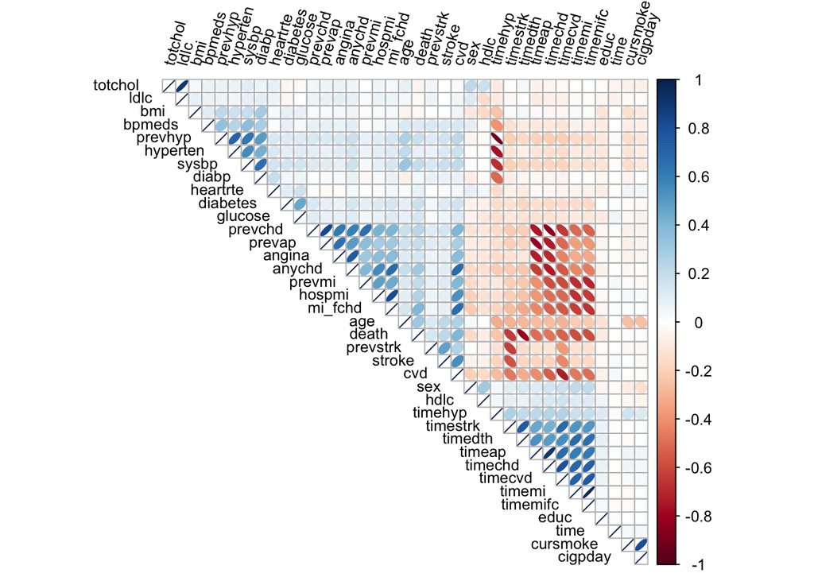

```r
library(dplyr)

corr <- data[,c(-1,-21)] %>% cor(., use = "complete.obs")

library(corrplot)

corrplot(corr, type = "upper", order = "hclust",
         tl.col = "black", tl.srt = 75,
         tl.offset = 1, tl.cex= .8, method = "ellipse")
```

## Missingness

```r
prop <- round(colSums(is.na(data))/dim(data)[1], 3)

knitr::kable(sort(prop, decreasing = TRUE)[1:9], col.names = "Proportion of NAs")
```

|  | Proportion of NAs |
| --- | --- |
| hdlc | 0.740 |
| ldlc | 0.740 |
| glucose | 0.124 |
| bpmeds | 0.051 |
| totchol | 0.035 |
| educ | 0.025 |
| cigpday | 0.007 |
| bmi | 0.004 |
| heartrte | 0.001 |

```r
prob.data <- data %>%
  group_by(period) %>%
  summarise(sysbp_prob = sum(sysbp, na.rm = TRUE)/n())
prob.data
```

| period | sysbp_prob |
| --- | --- |
| 1 | 132.9078 |
| 2 | 136.9475 |
| 3 | 140.2158 |

```r
table(data$period)
```

```
##
##    1    2    3
## 4434 3930 3263
```

# Models

```r
library(lme4)
library(dplyr)
```

## (1) Is there a relationship between age and smoking status? Does this relationship differ by sex?

```r
my.data <- read.csv("../final_data/frmgham2.csv")
library(gee)

model.q1 <- gee(CURSMOKE ~ AGE + as.factor(SEX) + as.factor(educ)
                 + BMI + DIABETES + HEARTRTE + PREVCHD + PREVSTRK
                 + PREVHYP + TIMEDTH,
                 id = RANDID,
                 data = my.data,
                 family=binomial,
                 corstr = "unstructured")
```

```
##      (Intercept)              AGE  as.factor(SEX)2 as.factor(educ)2
##     5.2810549757    -0.0570318456    -0.7246241605     0.0503157656
## as.factor(educ)3 as.factor(educ)4              BMI         DIABETES
##    -0.2263406725    -0.2104931713    -0.0940121564    -0.1114780579
##         HEARTRTE          PREVCHD         PREVSTRK          PREVHYP
##     0.0173911758    -0.0569530253    -0.2633153119    -0.2252617826
##          TIMEDTH
##    -0.0001021991
```

```r
knitr::kable(summary(model.q1)$coefficients[,c(1,4,5)], digits = 3)
```

|  | Estimate | Robust S.E. | Robust z |
| --- | --- | --- | --- |
| (Intercept) | 5.149 | 0.278 | 18.543 |
| AGE | -0.051 | 0.002 | -21.106 |
| as.factor(SEX)2 | -0.716 | 0.060 | -11.892 |
| as.factor(educ)2 | 0.083 | 0.071 | 1.168 |
| as.factor(educ)3 | -0.182 | 0.086 | -2.116 |
| as.factor(educ)4 | -0.212 | 0.097 | -2.185 |
| BMI | -0.084 | 0.007 | -12.152 |
| DIABETES | -0.060 | 0.102 | -0.595 |
| HEARTRTE | 0.009 | 0.001 | 6.031 |
| PREVCHD | -0.259 | 0.090 | -2.872 |
| PREVSTRK | -0.189 | 0.176 | -1.073 |
| PREVHYP | -0.049 | 0.041 | -1.187 |
| TIMEDTH | 0.000 | 0.000 | -6.341 |

```r
model.q1[["working.correlation"]]
```

```
##           [,1]      [,2]      [,3]
## [1,] 1.0000000 0.7563191 0.5136670
## [2,] 0.7563191 1.0000000 0.5713635
## [3,] 0.5136670 0.5713635 1.0000000
```

## (2) Is there a relationship between the number of cigarettes smoked per day and age? Does this relationship differ by sex?

```r
model.q2 <- lmer(CIGPDAY ~ AGE + as.factor(SEX) +
                   as.factor(educ) + (1|RANDID),
                  data = my.data)
```

If we think cig per day as count data, it follows poisson distribution. Then we can fit GEE model as well:

```r
model.q2_1 <- gee(CIGPDAY ~ AGE + as.factor(SEX) + as.factor(educ)
                 + BMI + DIABETES + HEARTRTE + PREVCHD + PREVSTRK
                 + PREVHYP + TIMEDTH,
                  data = my.data,
                  id = RANDID,
                  family=poisson,
                  corstr = "unstructured")
```

```
##      (Intercept)              AGE  as.factor(SEX)2 as.factor(educ)2
##     4.914149e+00    -3.395990e-02    -7.680017e-01     5.765596e-02
## as.factor(educ)3 as.factor(educ)4              BMI         DIABETES
##    -1.227240e-01    -8.833837e-02    -4.493994e-02    -1.608903e-01
##         HEARTRTE          PREVCHD         PREVSTRK          PREVHYP
##     1.281640e-02    -9.883049e-02    -1.115583e-01    -1.079832e-01
##          TIMEDTH
##    -5.152275e-05
```

```r
knitr::kable(summary(model.q2_1)$coefficients[,c(1,4,5)], digits = 3)
```

|  | Estimate | Robust S.E. | Robust z |
| --- | --- | --- | --- |
| (Intercept) | 4.523 | 0.170 | 26.626 |
| AGE | -0.024 | 0.001 | -15.826 |
| as.factor(SEX)2 | -0.795 | 0.039 | -20.223 |
| as.factor(educ)2 | 0.096 | 0.044 | 2.172 |
| as.factor(educ)3 | -0.072 | 0.057 | -1.245 |
| as.factor(educ)4 | -0.067 | 0.063 | -1.059 |
| BMI | -0.039 | 0.005 | -8.032 |
| DIABETES | -0.110 | 0.072 | -1.536 |
| HEARTRTE | 0.007 | 0.001 | 8.453 |
| PREVCHD | -0.241 | 0.066 | -3.635 |
| PREVSTRK | -0.130 | 0.110 | -1.181 |
| PREVHYP | -0.017 | 0.028 | -0.587 |
| TIMEDTH | 0.000 | 0.000 | -5.505 |

```r
model.q2_1[["working.correlation"]]
```

```
##           [,1]      [,2]      [,3]
## [1,] 1.0000000 0.7425318 0.5006078
## [2,] 0.7425318 1.0000000 0.6615306
## [3,] 0.5006078 0.6615306 1.0000000
```

Using mixed effect model using cig per day instead of smoking status:

```r
#saturated model
model.saturated <- lmer(CIGPDAY ~ as.factor(SEX) + AGE
                            + BPMEDS + as.factor(educ)
                            + TOTCHOL + BMI + GLUCOSE + DIABETES + HEARTRTE + PREVAP
                            + PREVCHD + PREVMI + PREVSTRK +STROKE+ PREVHYP + (1|RANDID),
                              na.action = 'na.omit',
                              data = my.data)
summary(model.saturated)
```

```
## Linear mixed model fit by REML ['lmerMod']
## Formula:
## CIGPDAY ~ as.factor(SEX) + AGE + BPMEDS + as.factor(educ) + TOTCHOL +
##     BMI + GLUCOSE + DIABETES + HEARTRTE + PREVAP + PREVCHD +
##     PREVMI + PREVSTRK + STROKE + PREVHYP + (1 | RANDID)
##    Data: my.data
##
## REML criterion at convergence: 67692.5
##
## Scaled residuals:
##     Min      1Q  Median      3Q     Max
## -4.4444 -0.3150 -0.1078  0.2067  6.2548
##
## Random effects:
##  Groups   Name        Variance Std.Dev.
##  RANDID   (Intercept) 95.78    9.787
##  Residual             35.77    5.981
## Number of obs: 9310, groups:  RANDID, 4213
##
## Fixed effects:
##                   Estimate Std. Error t value
## (Intercept)      23.237579   1.393589  16.675
## as.factor(SEX)2  -7.062484   0.339110 -20.827
## AGE              -0.178024   0.013735 -12.962
## BPMEDS            0.147068   0.340662   0.432
## as.factor(educ)2  0.602137   0.400578   1.503
## as.factor(educ)3 -0.984441   0.482907  -2.039
## as.factor(educ)4 -1.015103   0.548951  -1.849
## TOTCHOL           0.011407   0.002557   4.461
## BMI              -0.313257   0.035227  -8.893
## GLUCOSE          -0.010167   0.004203  -2.419
## DIABETES         -0.254321   0.570383  -0.446
## HEARTRTE          0.070622   0.008232   8.579
## PREVAP           -3.058426   0.985947  -3.102
## PREVCHD           0.948740   1.050262   0.903
## PREVMI           -2.594434   0.894896  -2.899
## PREVSTRK         -1.029740   0.917968  -1.122
## STROKE            0.943808   0.586941   1.608
## PREVHYP          -0.205972   0.240530  -0.856
```

```r
#using variables that selected
model.mixed2 <- lmer(CIGPDAY~ AGE + as.factor(SEX) + SYSBP
                      + DIABP + TOTCHOL + as.factor(educ)
                      + (1|RANDID),
                      data = my.data,
                      na.action = "na.omit")
summary(model.mixed2)
```

```
## Linear mixed model fit by REML ['lmerMod']
## Formula:
## CIGPDAY ~ AGE + as.factor(SEX) + SYSBP + DIABP + TOTCHOL + as.factor(educ) +
##     (1 | RANDID)
##    Data: my.data
##
## REML criterion at convergence: 78607.2
##
## Scaled residuals:
##     Min      1Q  Median      3Q     Max
## -4.6343 -0.3025 -0.1015  0.1642  6.6280
##
## Random effects:
##  Groups   Name        Variance Std.Dev.
##  RANDID   (Intercept) 97.30    9.864
##  Residual             36.52    6.043
## Number of obs: 10868, groups:  RANDID, 4306
##
## Fixed effects:
##                   Estimate Std. Error t value
## (Intercept)      21.750845   1.049612  20.723
## AGE              -0.199583   0.012148 -16.429
## as.factor(SEX)2  -6.448164   0.332812 -19.375
## SYSBP            -0.001364   0.006670  -0.205
## DIABP            -0.018833   0.011514  -1.636
## TOTCHOL           0.011959   0.002373   5.039
## as.factor(educ)2  1.055542   0.392720   2.688
## as.factor(educ)3 -0.625323   0.474072  -1.319
## as.factor(educ)4 -0.827192   0.539360  -1.534
##
## Correlation of Fixed Effects:
##             (Intr) AGE    a.(SEX SYSBP  DIABP  TOTCHO as.()2 as.()3
## AGE         -0.490
## as.fc(SEX)2 -0.144  0.019
## SYSBP        0.023 -0.460 -0.064
## DIABP       -0.452  0.314  0.076 -0.679
## TOTCHOL     -0.368 -0.095 -0.094  0.047 -0.154
## as.fctr(d)2 -0.225  0.110 -0.055  0.008  0.001  0.002
## as.fctr(d)3 -0.161  0.051 -0.092  0.028 -0.004 -0.007  0.351
## as.fctr(d)4 -0.175  0.044  0.074  0.032 -0.005 -0.002  0.301  0.244
```

```r
library(dplyr)

##################
# Initial Models #
##################


# totchol_fit <- gee(totchol ~ cursmoke + age + factor(sex) + factor(educ)  + bmi +
#              diabetes + heartrte + prevchd + prevhyp +  prevstrk + death,
#            id = randid,
#            family = "gaussian",
#            na.action = "na.omit")
#
# round(2 * pnorm(abs(coef(summary(totchol_fit))[,5]), lower.tail = FALSE), 3)
#
#
# sysbp_fit <- gee(sysbp ~ cursmoke + age + factor(sex) + factor(educ)  + bmi +
#                      diabetes + heartrte + prevchd + prevstrk + death,
#                    id = randid,
#                    family = "gaussian",
#                    na.action = "na.omit")
# round(2 * pnorm(abs(coef(summary(sysbp_fit))[,5]), lower.tail = FALSE), 3)
#
# diabp_fit <- gee(diabp ~ cursmoke + age + factor(sex) + factor(educ)  + bmi +
#                      diabetes + heartrte + prevchd + prevstrk +death,
#                    id = randid,
#                    family = "gaussian",
#                    na.action = "na.omit")
#
# round(2 * pnorm(abs(coef(summary(diabp_fit))[,5]), lower.tail = FALSE), 3)
```

## (3) Totchol and cursmoke

```r
###############################################
# Models After Removing Non Significant Terms #
###############################################

totchol_fit <- gee(totchol ~ cursmoke + age + factor(sex) + bmi +
                     diabetes + heartrte  + prevhyp ,
                   id = randid,
                   family = "gaussian",
                   corstr = "unstructured",
                   na.action = "na.omit")
```

```
##  (Intercept)     cursmoke          age factor(sex)2          bmi
##  162.1032803    2.3672102    0.6268036   12.3710689    0.7814908
##     diabetes     heartrte      prevhyp
##   -5.8194286    0.1891382    5.2800067
```

```r
knitr::kable(summary(totchol_fit)$coefficients[,c(1,4,5)], digits = 3)
```

|  | Estimate | Robust S.E. | Robust z |
| --- | --- | --- | --- |
| (Intercept) | 149.257 | 5.279 | 28.274 |
| cursmoke | 3.430 | 1.009 | 3.399 |
| age | 0.648 | 0.053 | 12.309 |
| factor(sex)2 | 13.474 | 1.219 | 11.050 |
| bmi | 1.404 | 0.144 | 9.748 |
| diabetes | -6.628 | 2.638 | -2.513 |
| heartrte | 0.117 | 0.032 | 3.626 |
| prevhyp | 3.451 | 0.903 | 3.820 |

```r
knitr::kable(round(2 * pnorm(abs(coef(summary(totchol_fit))[,5]), lower.tail = FALSE), 3))
```

|  | x |
| --- | --- |
| (Intercept) | 0.000 |
| cursmoke | 0.001 |
| age | 0.000 |
| factor(sex)2 | 0.000 |
| bmi | 0.000 |
| diabetes | 0.012 |
| heartrte | 0.000 |
| prevhyp | 0.000 |

```r
QIC(totchol_fit)
```

```
##      QIC
## 84588.89
```

```r
totchol_fit2 <- gee(totchol ~ cursmoke + age + factor(sex) + bmi +
                     diabetes + heartrte  + prevhyp ,
                   id = randid,
                   family = "gaussian",
                   corstr = "exchangeable",
                   na.action = "na.omit")
```

```
##  (Intercept)     cursmoke          age factor(sex)2          bmi
##  162.1032803    2.3672102    0.6268036   12.3710689    0.7814908
##     diabetes     heartrte      prevhyp
##   -5.8194286    0.1891382    5.2800067
```

```r
knitr::kable(summary(totchol_fit2)$coefficients[,c(1,4,5)], digits = 3)
```

|  | Estimate | Robust S.E. | Robust z |
| --- | --- | --- | --- |
| (Intercept) | 157.548 | 5.162 | 30.518 |
| cursmoke | 3.824 | 1.035 | 3.696 |
| age | 0.402 | 0.051 | 7.824 |
| factor(sex)2 | 13.291 | 1.222 | 10.874 |
| bmi | 1.656 | 0.143 | 11.578 |
| diabetes | -7.648 | 2.322 | -3.293 |
| heartrte | 0.118 | 0.033 | 3.607 |
| prevhyp | 2.423 | 0.894 | 2.710 |

```r
knitr::kable(round(2 * pnorm(abs(coef(summary(totchol_fit2))[,5]), lower.tail = FALSE), 3))
```

|  | x |
| --- | --- |
| (Intercept) | 0.000 |
| cursmoke | 0.000 |
| age | 0.000 |
| factor(sex)2 | 0.000 |
| bmi | 0.000 |
| diabetes | 0.001 |
| heartrte | 0.000 |
| prevhyp | 0.007 |

```r
QIC(totchol_fit2)
```

```
##      QIC
## 84588.27
```

## (4) Sysbp and cursmoke

```r
sysbp_fit <- gee(sysbp ~ cursmoke + age + factor(sex)  + bmi +
                   diabetes + heartrte + prevchd + prevstrk + death,
                 id = randid,
                 family = "gaussian",
                 corstr = "unstructured",
                 na.action = "na.omit")
```

```
##  (Intercept)     cursmoke          age factor(sex)2          bmi
##   40.1191453   -1.1246140    0.7236371    2.9078810    1.3070103
##     diabetes     heartrte      prevchd     prevstrk        death
##    4.8530466    0.2464253    2.4405511    8.6116353    7.0492511
```

```r
knitr::kable(summary(sysbp_fit)$coefficients[,c(1,4,5)], digits = 3)
```

|  | Estimate | Robust S.E. | Robust z |
| --- | --- | --- | --- |
| (Intercept) | 42.702 | 2.163 | 19.740 |
| cursmoke | -0.702 | 0.433 | -1.619 |
| age | 0.741 | 0.022 | 33.618 |
| factor(sex)2 | 3.272 | 0.542 | 6.042 |
| bmi | 1.373 | 0.062 | 22.301 |
| diabetes | 3.664 | 1.127 | 3.250 |
| heartrte | 0.175 | 0.016 | 11.231 |
| prevchd | 1.670 | 0.876 | 1.906 |
| prevstrk | 4.894 | 2.004 | 2.443 |
| death | 7.650 | 0.639 | 11.967 |

```r
knitr::kable(round(2 * pnorm(abs(coef(summary(sysbp_fit))[,5]), lower.tail = FALSE), 3))
```

|  | x |
| --- | --- |
| (Intercept) | 0.000 |
| cursmoke | 0.105 |
| age | 0.000 |
| factor(sex)2 | 0.000 |
| bmi | 0.000 |
| diabetes | 0.001 |
| heartrte | 0.000 |
| prevchd | 0.057 |
| prevstrk | 0.015 |
| death | 0.000 |

```r
QIC(sysbp_fit)
```

```
##      QIC
## 68837.26
```

```r
sysbp_fit2 <- gee(sysbp ~ cursmoke + age + factor(sex)  + bmi +
                   diabetes + heartrte + prevchd + prevstrk + death,
                 id = randid,
                 family = "gaussian",
                 corstr = "exchangeable",
                 na.action = "na.omit")
```

```
##  (Intercept)     cursmoke          age factor(sex)2          bmi
##   40.1191453   -1.1246140    0.7236371    2.9078810    1.3070103
##     diabetes     heartrte      prevchd     prevstrk        death
##    4.8530466    0.2464253    2.4405511    8.6116353    7.0492511
```

```r
knitr::kable(summary(sysbp_fit2)$coefficients[,c(1,4,5)], digits = 3)
```

|  | Estimate | Robust S.E. | Robust z |
| --- | --- | --- | --- |
| (Intercept) | 43.000 | 2.176 | 19.758 |
| cursmoke | -0.772 | 0.431 | -1.789 |
| age | 0.741 | 0.021 | 34.477 |
| factor(sex)2 | 3.321 | 0.545 | 6.093 |
| bmi | 1.370 | 0.063 | 21.783 |
| diabetes | 3.173 | 1.114 | 2.848 |
| heartrte | 0.172 | 0.016 | 10.967 |
| prevchd | 1.553 | 0.862 | 1.800 |
| prevstrk | 4.201 | 2.094 | 2.006 |
| death | 7.794 | 0.644 | 12.109 |

```r
knitr::kable(round(2 * pnorm(abs(coef(summary(sysbp_fit2))[,5]), lower.tail = FALSE), 3))
```

|  | x |
| --- | --- |
| (Intercept) | 0.000 |
| cursmoke | 0.074 |
| age | 0.000 |
| factor(sex)2 | 0.000 |
| bmi | 0.000 |
| diabetes | 0.004 |
| heartrte | 0.000 |
| prevchd | 0.072 |
| prevstrk | 0.045 |
| death | 0.000 |

```r
QIC(sysbp_fit2)
```

```
##      QIC
## 68837.55
```

## (5) Diabp and cursmoke

```r
diabp_fit <- gee(diabp ~ cursmoke + factor(sex) + factor(educ) + bmi +
                   diabetes + heartrte  + prevstrk +death,
                 id = randid,
                 family = "gaussian",
                 corstr = "unstructured",
                 na.action = "na.omit")
```

```
##   (Intercept)      cursmoke  factor(sex)2 factor(educ)2 factor(educ)3
##    47.3480563    -1.0968017    -0.8594048     0.7880155     0.6921165
## factor(educ)4           bmi      diabetes      heartrte      prevstrk
##     0.5395935     0.9078065    -1.6162433     0.1550842     4.3067909
##         death
##     2.8662538
```

```r
knitr::kable(summary(diabp_fit)$coefficients[,c(1,4,5)], digits = 3)
```

|  | Estimate | Robust S.E. | Robust z |
| --- | --- | --- | --- |
| (Intercept) | 48.560 | 1.142 | 42.511 |
| cursmoke | -0.607 | 0.243 | -2.501 |
| factor(sex)2 | -0.591 | 0.295 | -1.999 |
| factor(educ)2 | 0.864 | 0.344 | 2.513 |
| factor(educ)3 | 0.769 | 0.400 | 1.924 |
| factor(educ)4 | 0.470 | 0.450 | 1.043 |
| bmi | 0.971 | 0.035 | 28.015 |
| diabetes | -1.731 | 0.598 | -2.895 |
| heartrte | 0.112 | 0.009 | 12.846 |
| prevstrk | 1.842 | 1.207 | 1.526 |
| death | 3.219 | 0.336 | 9.582 |

```r
knitr::kable(round(2 * pnorm(abs(coef(summary(diabp_fit))[,5]), lower.tail = FALSE), 3))
```

|  | x |
| --- | --- |
| (Intercept) | 0.000 |
| cursmoke | 0.012 |
| factor(sex)2 | 0.046 |
| factor(educ)2 | 0.012 |
| factor(educ)3 | 0.054 |
| factor(educ)4 | 0.297 |
| bmi | 0.000 |
| diabetes | 0.004 |
| heartrte | 0.000 |
| prevstrk | 0.127 |
| death | 0.000 |

```r
QIC(diabp_fit)
```

```
##      QIC
## 53507.67
```

```r
diabp_fit2 <- gee(diabp ~ cursmoke + factor(sex) + factor(educ) + bmi +
                   diabetes + heartrte  + prevstrk +death,
                 id = randid,
                 family = "gaussian",
                 corstr = "exchangeable",
                 na.action = "na.omit")
```

```
##   (Intercept)      cursmoke  factor(sex)2 factor(educ)2 factor(educ)3
##    47.3480563    -1.0968017    -0.8594048     0.7880155     0.6921165
## factor(educ)4           bmi      diabetes      heartrte      prevstrk
##     0.5395935     0.9078065    -1.6162433     0.1550842     4.3067909
##         death
##     2.8662538
```

```r
knitr::kable(summary(diabp_fit2)$coefficients[,c(1,4,5)], digits = 3)
```

|  | Estimate | Robust S.E. | Robust z |
| --- | --- | --- | --- |
| (Intercept) | 48.526 | 1.156 | 41.980 |
| cursmoke | -0.525 | 0.242 | -2.166 |
| factor(sex)2 | -0.518 | 0.298 | -1.738 |
| factor(educ)2 | 0.857 | 0.346 | 2.476 |
| factor(educ)3 | 0.776 | 0.403 | 1.927 |
| factor(educ)4 | 0.531 | 0.453 | 1.171 |
| bmi | 0.991 | 0.035 | 28.079 |
| diabetes | -2.072 | 0.582 | -3.564 |
| heartrte | 0.106 | 0.009 | 12.102 |
| prevstrk | 1.049 | 1.215 | 0.863 |
| death | 3.317 | 0.338 | 9.800 |

```r
knitr::kable(round(2 * pnorm(abs(coef(summary(diabp_fit2))[,5]), lower.tail = FALSE), 3))
```

|  | x |
| --- | --- |
| (Intercept) | 0.000 |
| cursmoke | 0.030 |
| factor(sex)2 | 0.082 |
| factor(educ)2 | 0.013 |
| factor(educ)3 | 0.054 |
| factor(educ)4 | 0.241 |
| bmi | 0.000 |
| diabetes | 0.000 |
| heartrte | 0.000 |
| prevstrk | 0.388 |
| death | 0.000 |

```r
QIC(diabp_fit2)
```

```
##   QIC
## 53508
```